# Onderzoek informatie Delos

Data inladen.

```python
import json
import pandas as pd
import seaborn as sns
import matplotlib.pyplot as plt
from datetime import datetime
import folium
from folium.plugins import HeatMap

data= pd.read_json('deep-dive-westworld-starter-kit/data/incident_reports.json')
data
```

|  | incident_id | timestamp | latitude | longitude | type | severity | point_of_interest |
| --- | --- | --- | --- | --- | --- | --- | --- |
| 0 | INC-2022-09-01-1 | 2022-09-01 03:31:00 | 963.527206 | 1524.588192 | Decor destroyed | High | Ghost Nation |
| 1 | INC-2022-09-01-2 | 2022-09-01 01:28:00 | 952.309471 | 897.776679 | Decor destroyed | High | Badlands |
| 2 | INC-2022-09-01-3 | 2022-09-01 04:11:00 | 1371.138688 | 1013.825556 | Terrain destroyed | High | Python Pass |
| 3 | INC-2022-09-01-4 | 2022-09-01 06:58:00 | 498.863433 | 829.139805 | Narrative ended | Critical | Badlands |
| 4 | INC-2022-09-01-5 | 2022-09-01 09:28:00 | 1238.207477 | 780.508606 | Narrative ended | Low | Sweetwater |
| ... | ... | ... | ... | ... | ... | ... | ... |
| 1708 | INC-2023-08-30-1709 | 2023-08-30 08:16:00 | 1131.665480 | 676.369704 | Host Destroyed | Medium | Mines |
| 1709 | INC-2023-08-30-1710 | 2023-08-30 15:20:00 | 969.165055 | 983.248243 | Terrain destroyed | Low | Sweetwater |
| 1710 | INC-2023-08-30-1711 | 2023-08-30 06:41:00 | 1109.564653 | 778.904673 | Malfunction | Medium | Badlands |
| 1711 | INC-2023-08-30-1712 | 2023-08-30 18:17:00 | 1396.356434 | 392.574895 | Narrative ended | Medium | Las Mudas |
| 1712 | INC-2023-08-30-1713 | 2023-08-30 11:43:00 | 514.986343 | 1601.500422 | Malfunction | Medium | Maeve's Homestead |

1713 rows × 7 columns

## Incidenten type

Sorteren incindenten per type

```python
types = data['type'].unique()
types
```

```
array(['Decor destroyed', 'Terrain destroyed', 'Narrative ended',
       'Malfunction', 'Host Destroyed'], dtype=object)
```

Tellen van incidenten per types

```python
tellen=data['type'].value_counts()
print(tellen)
```

```
Host Destroyed       630
Decor destroyed      280
Terrain destroyed    274
Malfunction          266
Narrative ended      263
Name: type, dtype: int64
```

Cirkeldiagram van aantal incidenten per type

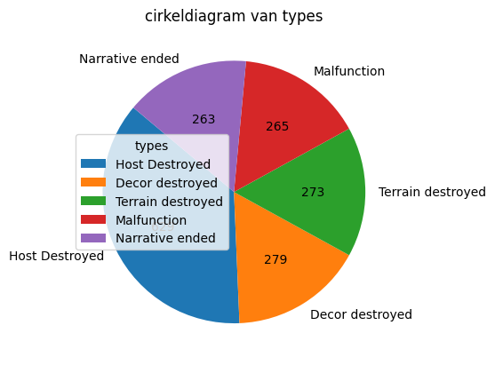

```python
plt.pie(tellen,labels=tellen.index , autopct=lambda p:f'{int(p * sum(tellen) / 100)}', startangle=140)
plt.legend(tellen.index, title = 'types', )
plt.title('cirkeldiagram van types')
plt.show()
```

Staafdiagram van aantal incidenten per type

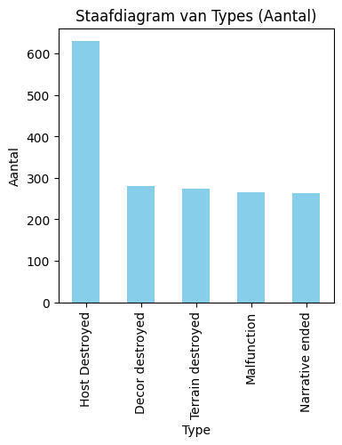

```python
plt.figure(figsize=(4, 4))

tellen.plot(kind='bar', color='skyblue')

plt.xlabel('Type')
plt.ylabel('Aantal')

plt.title("Staafdiagram van Types (Aantal)")

plt.show()
```

## Tijdreekanalyse

Waneer zijn de incidenten gebeurt per dag van de week.

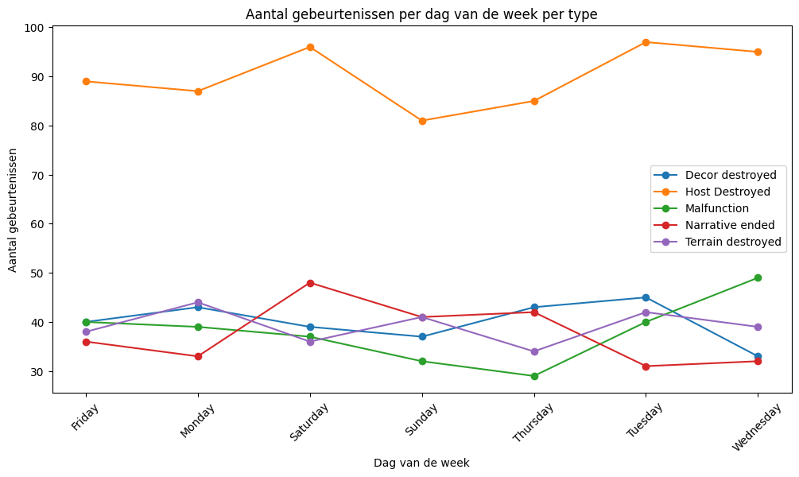

```python
data['timestamp'] = pd.to_datetime(data['timestamp'])
data['dagvanweek'] = data['timestamp'].dt.day_name()
tellingdag = data.groupby(['type', 'dagvanweek']).size().reset_index(name='aantal_gebeurtenissen')
plt.figure(figsize=(12, 6))

for incident_type in tellingdag['type'].unique():
    data1 = tellingdag[tellingdag['type'] == incident_type]
    plt.plot(data1['dagvanweek'], data1['aantal_gebeurtenissen'], marker='o', label=incident_type)

plt.xlabel('Dag van de week')
plt.ylabel('Aantal gebeurtenissen')

plt.title("Aantal gebeurtenissen per dag van de week per type")

plt.xticks(rotation=45)

plt.legend()
```

Waneer zijn de incidenten gebeurt per maand van het jaar.

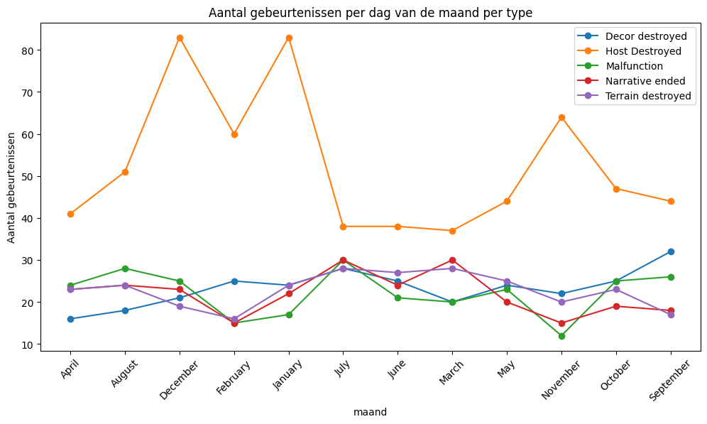

```python
data['timestamp'] = pd.to_datetime(data['timestamp'])
data['dagvanmaand'] = data['timestamp'].dt.month_name()
tellingdag = data.groupby(['type','dagvanmaand']).size().reset_index(name='aantal_gebeurtenissen')
plt.figure(figsize=(12, 6))

for incident_type in tellingdag['type'].unique():
    data2 = tellingdag[tellingdag['type'] == incident_type]
    plt.plot(data2['dagvanmaand'], data2['aantal_gebeurtenissen'], marker='o', label=incident_type)

plt.xlabel('maand')
plt.ylabel('Aantal gebeurtenissen')

plt.title("Aantal gebeurtenissen per dag van de maand per type")

plt.xticks(rotation=45)

plt.legend()
```

## Heatmap

Hotspots tonen.

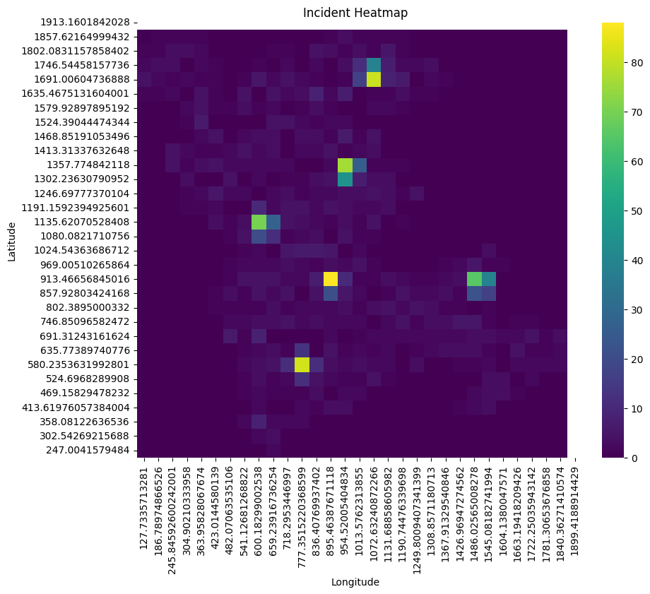

```python
import folium
from folium.plugins import HeatMap
import numpy as np

latitude_bins = 30
longitude_bins = 30

hist2d, xedges, yedges = np.histogram2d(
    data['longitude'], data['latitude'], bins=(longitude_bins, latitude_bins)
)

plt.figure(figsize=(10, 8))
sns.heatmap(hist2d.T, cmap='viridis', xticklabels=xedges, yticklabels=yedges)
plt.xlabel('Longitude')
plt.ylabel('Latitude')
plt.title('Incident Heatmap')
plt.gca().invert_yaxis()

plt.show()
```

Hotspot op kaart brengen.

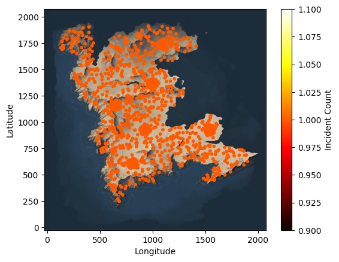

```python
import pandas as pd
import matplotlib.pyplot as plt
import matplotlib.image as mpimg

incident_counts = data.groupby(['latitude', 'longitude']).size().reset_index(name='incident_count')
background_image = mpimg.imread('deep-dive-westworld-starter-kit/images/map.png')

center_x = 1024
center_y = 1024

image_width = background_image.shape[1]
image_height = background_image.shape[0]

extent = [
    center_x - (2100 / 2),
    center_x + (2100/ 2),
    center_y - (2100 / 2),
    center_y + (2100/ 2)
]

fig, ax = plt.subplots()

ax.imshow(background_image, extent=extent)

heatmap = ax.scatter(incident_counts['longitude'], incident_counts['latitude'], c=incident_counts['incident_count'], cmap='hot', s=10)

plt.xlabel('Longitude')
plt.ylabel('Latitude')
plt.colorbar(heatmap, label='Incident Count')

plt.show()
```

## Aantal bezoekers

Data inladen

```python
import json
import pandas as pd
import matplotlib.pyplot as plt
import numpy as np


dat= pd.read_json('deep-dive-westworld-starter-kit/data/visitor_data.json')
dat
```

|  | Date | Total_Visitors | Male_Visitors | Female_Visitors |
| --- | --- | --- | --- | --- |
| 0 | 2022-09-01 | 285 | 142 | 143 |
| 1 | 2022-09-02 | 129 | 64 | 65 |
| 2 | 2022-09-03 | 177 | 88 | 89 |
| 3 | 2022-09-04 | 129 | 64 | 65 |
| 4 | 2022-09-05 | 151 | 75 | 76 |
| ... | ... | ... | ... | ... |
| 359 | 2023-08-26 | 268 | 134 | 134 |
| 360 | 2023-08-27 | 133 | 66 | 67 |
| 361 | 2023-08-28 | 107 | 53 | 54 |
| 362 | 2023-08-29 | 286 | 143 | 143 |
| 363 | 2023-08-30 | 127 | 63 | 64 |

364 rows × 4 columns

Verander van datum naar jaar en maand.

```python
df = pd.DataFrame(dat)

df['Date'] = pd.to_datetime(df['Date'])

df['Year'] = df['Date'].dt.year
df['Month'] = df['Date'].dt.month

monthly_visitors = df.groupby(['Year', 'Month'])[['Total_Visitors', 'Male_Visitors', 'Female_Visitors']].sum().reset_index()

monthly_visitors
```

|  | Year | Month | Total_Visitors | Male_Visitors | Female_Visitors |
| --- | --- | --- | --- | --- | --- |
| 0 | 2022 | 9 | 5743 | 2863 | 2880 |
| 1 | 2022 | 10 | 5833 | 2908 | 2925 |
| 2 | 2022 | 11 | 5832 | 3488 | 2344 |
| 3 | 2022 | 12 | 7717 | 4617 | 3100 |
| 4 | 2023 | 1 | 7989 | 4781 | 3208 |
| 5 | 2023 | 2 | 5707 | 3414 | 2293 |
| 6 | 2023 | 3 | 6230 | 3108 | 3122 |
| 7 | 2023 | 4 | 6102 | 3045 | 3057 |
| 8 | 2023 | 5 | 6109 | 3047 | 3062 |
| 9 | 2023 | 6 | 6198 | 3091 | 3107 |
| 10 | 2023 | 7 | 6893 | 3437 | 3456 |
| 11 | 2023 | 8 | 5948 | 2968 | 2980 |

Aantal bezoekers per man en vrouw per datum.

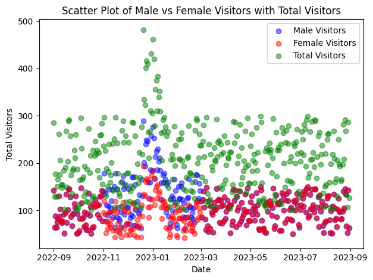

[figure not shown]

```python
df = pd.DataFrame(dat)

df['Date'] = pd.to_datetime(df['Date'])

fig, ax = plt.subplots()

plt.figure(figsize=(10, 8))

ax.scatter(df['Date'], df['Male_Visitors'], label='Male Visitors', color='blue', alpha=0.5)

ax.scatter(df['Date'], df['Female_Visitors'], label='Female Visitors', color='red', alpha=0.5)

ax.scatter(df['Date'], df['Total_Visitors'], label='Total Visitors', color='green', alpha=0.5)

ax.set_xlabel('Date')
ax.set_ylabel('Total Visitors')
ax.set_title('Scatter Plot of Male vs Female Visitors with Total Visitors')

plt.xticks(df['Date'], rotation=50)

ax.legend()

fig.tight_layout()

plt.show()
```

# Ernst

Hoe ernstig zijn de incidenten per type.

```python
incident_types = data['type']
incident_types
```

```
0         Decor destroyed
1         Decor destroyed
2       Terrain destroyed
3         Narrative ended
4         Narrative ended
              ...
1708       Host Destroyed
1709    Terrain destroyed
1710          Malfunction
1711      Narrative ended
1712          Malfunction
Name: type, Length: 1713, dtype: object
```

Hoogte van ernst naar boven halen.

```python
severity = data['severity']
severity
```

```
0           High
1           High
2           High
3       Critical
4            Low
          ...
1708      Medium
1709         Low
1710      Medium
1711      Medium
1712      Medium
Name: severity, Length: 1713, dtype: object
```

Tellen per type hoeveel incidenten.

```python
incident_counts = data.groupby('type')['severity'].count()
incident_counts
```

```
type
Decor destroyed      280
Host Destroyed       630
Malfunction          266
Narrative ended      263
Terrain destroyed    274
Name: severity, dtype: int64
```

Histogram aantal incidenten per type.

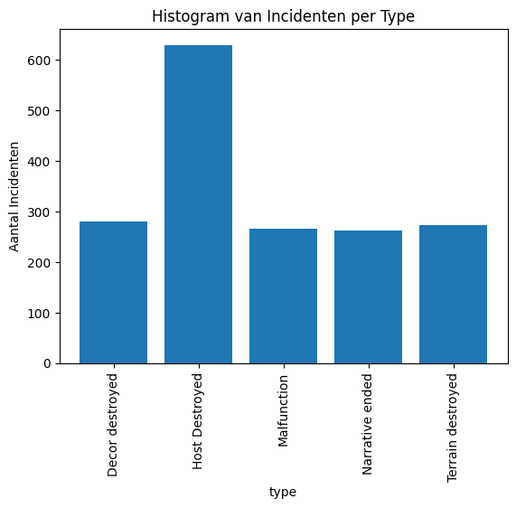

```python
plt.bar(incident_counts.index, incident_counts.values)
plt.xlabel('type')
plt.ylabel('Aantal Incidenten')
plt.title('Histogram van Incidenten per Type')
plt.xticks(rotation=90)
plt.show()
```

Tellen hoeveel incidenten in severity.

```python
ernst=data['severity'].value_counts()
print(ernst)
```

```
High        650
Low         359
Medium      357
Critical    347
Name: severity, dtype: int64
```

Aantal incidenten per type. En hoevel van welke severity er is per type.

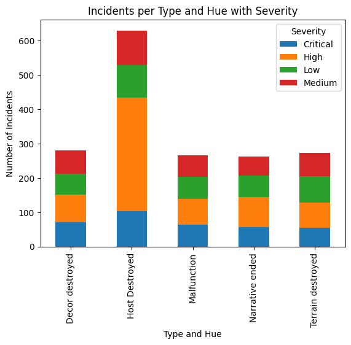

```python
df = pd.DataFrame(data)

grouped_data = df.groupby(['type',  'severity']).size().unstack(fill_value=0)

plt.figure(figsize=(12, 6))

grouped_data.plot(kind='bar', stacked=True)

plt.xlabel('Type and Hue')

plt.ylabel('Number of Incidents')

plt.title('Incidents per Type and Hue with Severity')

plt.xticks(rotation=90)

plt.legend(title='Severity')

plt.show()
```

Zelfde als hier boven alleen Severity naast elkaar.

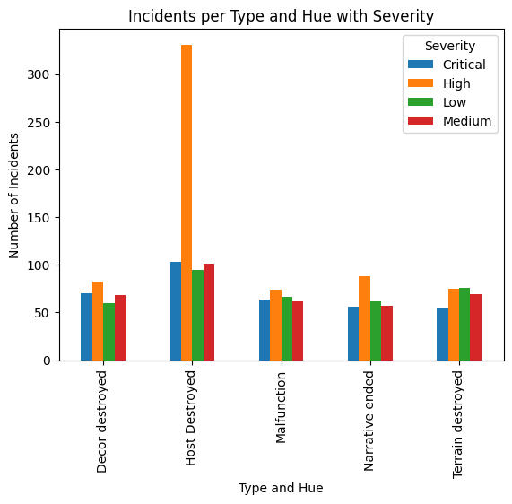

```python
df = pd.DataFrame(data)

grouped_data = df.groupby(['type',  'severity']).size().unstack(fill_value=0)

plt.figure(figsize=(12, 6))

grouped_data.plot(kind='bar')

plt.xlabel('Type and Hue')

plt.ylabel('Number of Incidents')

plt.title('Incidents per Type and Hue with Severity')

plt.xticks(rotation=90)

plt.legend(title='Severity')

plt.show()
```

## Conclusie

In het park zijn er 5 verschillende incidenten plaats gevonden. De incident dat het vaakste plaats vind is Host Destroyed.

Deze incidenten vinden het vaakste plaats op Zaterdag, Dinsdag en woensdag. De maanden dat dit het vaakste plaats vind in januari, November en december.

De incidenten komen het meest voor bij de delen: Pariah, Gost nation, Badland, mines, Python pas, The virgils last stand. En van deze is de Plek waar de meeste incidenten gebeurd badland.

De meeste bezoekers zijn gekomen in December en januari. Onder de bezoekers komen het meeste mannen.

Dus hoe hoger aantal bezoeker hoe meer incidenten er gebeuren. dit zal waarschijnlijk hier mee te maken hebben.

Bij de verschillende type komen bij de meeste de Severity everedig overeen. behalven bij de Host Destroyed. hierbij zijn de incidenten van severity High.

## Tunnel systeem

De gekozen tunnel en plekken voor de opruim crew.

[figure not shown]

```python
from PIL import Image
import matplotlib.pyplot as plt

img = Image.open('map.png')
plt.imshow(img)
```

### Conclusie tunnel systeem

Wij hebben er voor gekozen om de tunnel te laten leiden van Pariah -> Badlands -> Mesa. Dit hebben we gedaan omdat bij ons onderzoek er uit kwam dat Pariah en Badlands 2 van de 5 plekken is waar veel incidenten gebeuren. Waarvan Badlands de meeste van al gebeuren. dan hebben we nog een tunnel van Ghost nation -> Badlands en die gaat dan ntuurlijk weer van daar naar Mesa. Dit is ook omdat dit 1 van de plekken met veel incidenten is. En dat als laaste hebben we nog een tunnel van Virgil's last stand -> Python pass -> Mesa. Dat zijn bij elkaar de 5 plekken met de meeste incidenten. Toen hebben we nog een keuzen moeten maken voor de opruim crew. En hebben hier voor gekozen om het eerste huisje bij Badlands te zetten omdat dit de plek is met de meeste incidenten en Paraih kan dan ook geholpen worden door middel van de tunnels. Voor de rest hebben we nog 1 bij Ghost nation gezet omdat die er afgelegen lag en hierdoor niet lang gereist hoeft te worden naar een plek met veel incidenten. Ook hebben we een bij Mesa gezet dit is een plek die erg centraal licht dus die kan over snel zijn omdat hij overal tunnel naar toe heeft leiden. En als laatse hebben we een huisje bij Virgil's last stand gezet ook omdat hij erg afgelegen licht en veel incidenten heeft.